# PBS Utah Donor Project: Exploratory Data Analysis

Author

Owen Simon

## Setup

```r
# Load only packages required to import, summarize, and plot the project data.
library(dplyr)
library(gt)
library(ggplot2)
library(knitr)
library(readr)
library(tibble)
library(sf)
library(tigris)
library(stringr)
library(scales)
library(tidyr)

# Use one relative path so the report can run from the project root.
data_dir <- "Data_Files"

# Read a data file quietly and consistently.
read_project_csv <- function(file_name) {
  read_csv(file.path(data_dir, file_name), show_col_types = FALSE, progress = FALSE)
}

# Calculate PBS fiscal year, where July--December belong to the next fiscal year.
fiscal_year <- function(date) {
  as.integer(format(date, "%Y")) + as.integer(format(date, "%m") >= 7)
}

# Summarize a table without printing or retaining its raw records.
profile_data <- function(data, file_name, key = NULL) {
  key_missing <- key_duplicates <- NA_integer_
  if (!is.null(key) && key %in% names(data)) {
    values <- data[[key]]
    key_missing <- sum(is.na(values) | values == "")
    key_duplicates <- sum(duplicated(values[!is.na(values) & values != ""]))
  }
  tibble(file = file_name, rows = nrow(data), columns = ncol(data),
         key = key,
         missing_key_values = key_missing, duplicate_nonmissing_keys = key_duplicates)
}

# Report blank strings and missing values for each field.
missingness <- function(data) {
  tibble(field = names(data),
         missing_n = vapply(data, function(x) sum(is.na(x) | x == ""), integer(1))) %>%
    mutate(missing_pct = round(100 * missing_n / nrow(data), 2)) %>%
    arrange(desc(missing_pct), desc(missing_n))
}

# Render compact summary tables with readable numbers.
show_table <- function(x) kable(x, format = "html", digits = 2,
                                format.args = list(big.mark = ","))
```

## Data Inventory

The table grain is essential context for joins. A constituent, payment, legacy household gift, solicitation, soft credit, cultivation assignment, and viewing record are not interchangeable units.

```r
# Document all expected inputs and verify that they are present in the repository.
inventory <- tribble(
  ~file, ~grain, ~documented_key,
  "constituents_w_memberships.csv", "constituent", "Constituent ID",
  "unite_payments.csv", "payment", "payment_id",
  "team_approach_legacy_payments.csv", "legacy household gift", "ta_account_id",
  "soft_credits.csv", "soft credit", "Credit ID",
  "campaign_codes.csv", "marketing code reference", "Marketing Code",
  "campaign_members.csv", "solicitation", "none documented",
  "cultivation.csv", "constituent-year assignment", "synthetic_id plus fiscal_year",
  "officer_portfolios.csv", "portfolio", "portfolio_id",
  "passport_viewing.csv", "viewing record", "UID"
) %>%
  mutate(available = file.exists(file.path(data_dir, file)),
         bytes = if_else(available, file.info(file.path(data_dir, file))$size, NA_real_))
```

```r
gt(inventory) |>
  tab_header(
    title = "Data File Library")
```

Data File Library

| file | grain | documented_key | available | bytes |
| --- | --- | --- | --- | --- |
| constituents_w_memberships.csv | constituent | Constituent ID | TRUE | 20853158 |
| unite_payments.csv | payment | payment_id | TRUE | 264906264 |
| team_approach_legacy_payments.csv | legacy household gift | ta_account_id | TRUE | 241557050 |
| soft_credits.csv | soft credit | Credit ID | TRUE | 400636 |
| campaign_codes.csv | marketing code reference | Marketing Code | TRUE | 3750569 |
| campaign_members.csv | solicitation | none documented | TRUE | 408835157 |
| cultivation.csv | constituent-year assignment | synthetic_id plus fiscal_year | TRUE | 166582 |
| officer_portfolios.csv | portfolio | portfolio_id | TRUE | 255 |
| passport_viewing.csv | viewing record | UID | TRUE | 136 |

## Constituents and Memberships

This entity table supplies donor attributes. First check the documented identifier, missingness, demographic distributions, and current membership attributes. Current snapshot variables must not be used as historical values.

```r
# Load the entity table and create only summaries needed for the report.
constituents <- read_project_csv("constituents_w_memberships.csv")

constituent_profile <- profile_data(constituents, "constituents_w_memberships.csv", "Constituent ID")

constituent_missing <- missingness(constituents)

constituent_summary <- constituents %>%
  summarise(unique_ids = n_distinct(.data[["Constituent ID"]]),
            median_age = median(Age, na.rm = TRUE),
            sustainers = sum(.data[["Sustainer PBS Utah"]], na.rm = TRUE),
            sustainer_pct = 100 * mean(.data[["Sustainer PBS Utah"]], na.rm = TRUE))

segments <- constituents %>%
  count(.data[["Primary Constituent Type"]], Gender, .data[["Sustainer PBS Utah"]], sort = TRUE)
```

```r
gt(constituent_profile) |>
  tab_header(
    title = "Constituent Data Profile"
  )
```

Constituent Data Profile

| file | rows | columns | key | missing_key_values | duplicate_nonmissing_keys |
| --- | --- | --- | --- | --- | --- |
| constituents_w_memberships.csv | 196167 | 22 | Constituent ID | 0 | 0 |

196,167 rows; no duplicates; no missing key values

```r
gt(constituent_summary) |>
  tab_header(
    title = "Constituent Summary"
  )
```

Constituent Summary

| unique_ids | median_age | sustainers | sustainer_pct |
| --- | --- | --- | --- |
| 196167 | 68 | 27308 | 13.92093 |

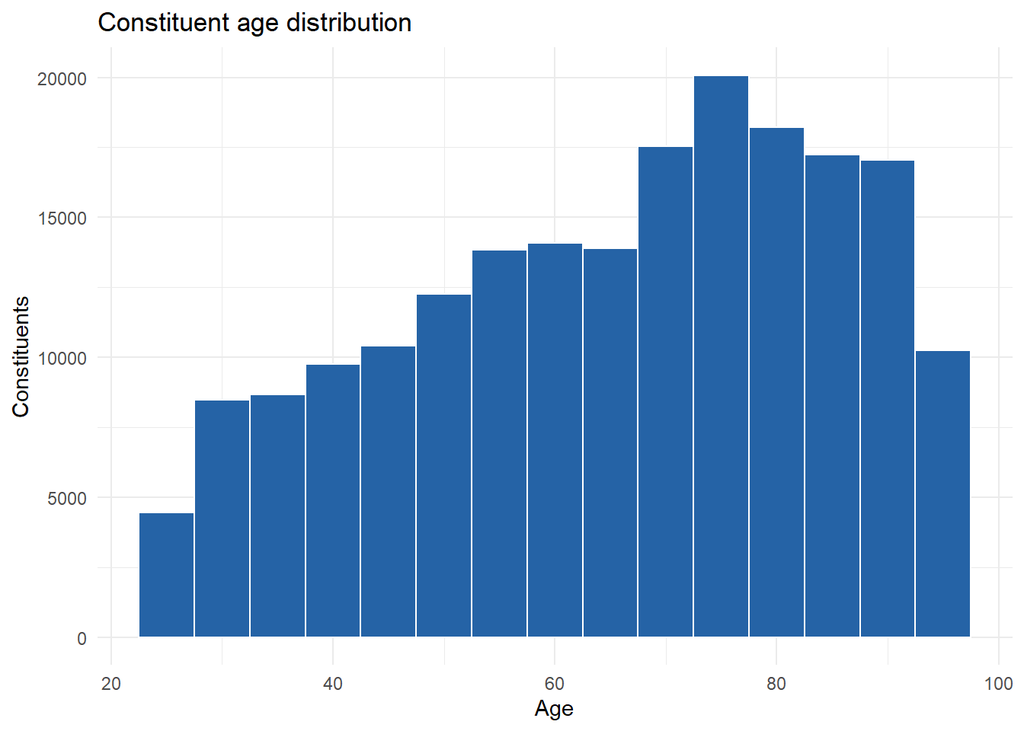

```r
# Plot the age distribution only for records with known ages.
ggplot(filter(constituents, !is.na(Age)), aes(Age)) +
  geom_histogram(binwidth = 5, fill = "#2563A6", color = "white") +
  labs(title = "Constituent age distribution", x = "Age", y = "Constituents") +
  theme_minimal()
```

The median constituent age is 68 years old; 13.92% of constituents are PBS Utah sustainers (giving a monthly recurring gift).

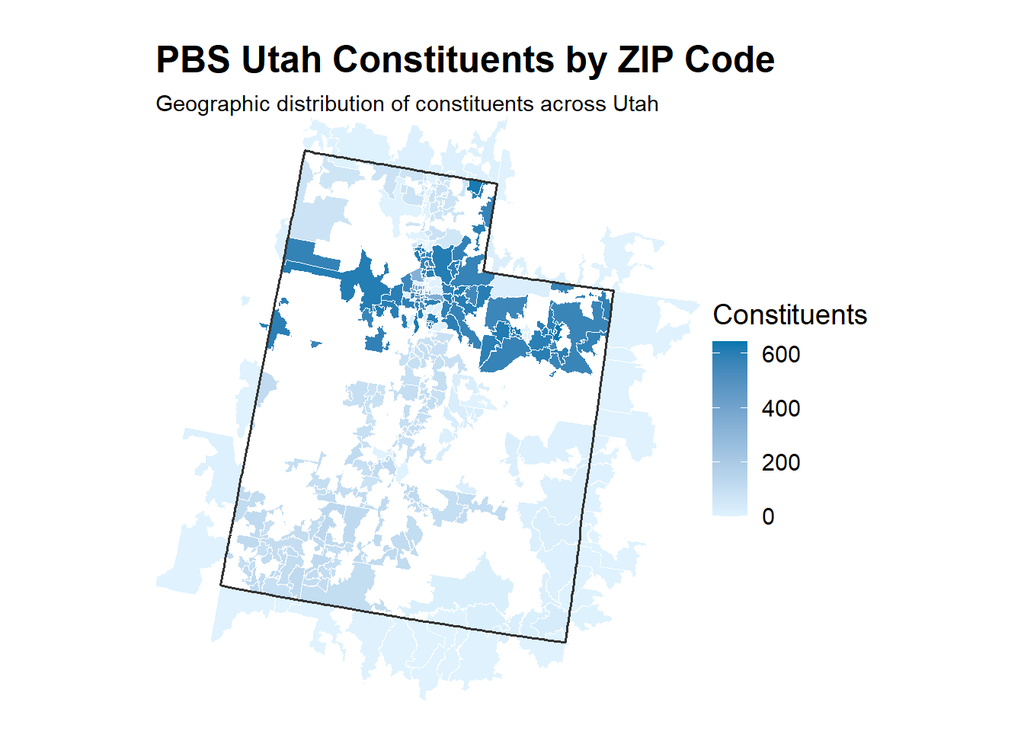

```r
# Keep ZCTAs intersecting Utah
utah_zips <- us_zips |>
  st_transform(5070) |>
  st_filter(utah) |>
  mutate(zip = ZCTA5CE20)

utah_map <- utah_zips |>
  left_join(zip_summary, by = "zip") |>
  mutate(
    constituents = replace_na(constituents, 0)
  )

utah_zip_map <- ggplot() +
  geom_sf(
    data = utah_map,
    aes(fill = constituents),
    color = "white",
    linewidth = 0.1
  ) +
  geom_sf(
    data = utah,
    fill = NA,
    color = "#333333",
    linewidth = 0.6
  ) +
  scale_fill_gradient(
    low = "#dff2fe",
    high = "#0377af",
    labels = comma,
    name = "Constituents"
  ) +
  coord_sf(expand = FALSE) +
  labs(
    title = "PBS Utah Constituents by ZIP Code",
    subtitle = "Geographic distribution of constituents across Utah"
  ) +
  theme_void(base_size = 14) +
  theme(
    plot.title = element_text(face = "bold", size = 18),
    plot.subtitle = element_text(size = 11),
    legend.position = "right",
    plot.margin = margin(15, 15, 15, 15)
  )

utah_zip_map
```

```r
zip_summary |>
  arrange(desc(constituents)) |>
  head() |>
  gt() |>
  tab_header(title = "Constituents by ZIP Code") |>
  cols_label(
    zip = "ZIP Code",
    constituents = "Constituents"
  ) |>
  fmt_number(columns = constituents, decimals = 0)
```

Constituents by ZIP Code

| ZIP Code | Constituents |
| --- | --- |
| 84000 | 18,211 |
| 84100 | 14,126 |
| 84700 | 3,489 |
| 84600 | 3,249 |
| 84400 | 2,866 |
| 84300 | 2,447 |

```
Placeholder '84000' ZIP code used for 27.81 percent of Utah constituents.
```

```r
gt(head(constituent_missing, 12))
```

| field | missing_n | missing_pct |
| --- | --- | --- |
| UofU Degree Info | 196167 | 100.00 |
| Latest UofU Degree Year | 196167 | 100.00 |
| UofU Employment Status | 196167 | 100.00 |
| Major Donor Class PBS Utah | 195608 | 99.72 |
| Spouse Constituent ID | 178807 | 91.15 |
| Marital Status | 178807 | 91.15 |
| Address City | 51497 | 26.25 |
| Address ZIP | 2 | 0.00 |
| Age | 2 | 0.00 |
| Annual Giving Group | 2 | 0.00 |
| UofU Degree Count | 2 | 0.00 |
| Gender | 2 | 0.00 |

- UofU Degree Info
- Latest UofU Degree Year
- UofU Employment Status
- Major Donor Class PBS Utah
- Spouse Constituent ID
- Marital Status

```r
gt(head(segments, 15))
```

| Primary Constituent Type | Gender | Sustainer PBS Utah | n |
| --- | --- | --- | --- |
| Friends | Female | FALSE | 46384 |
| Friends | Male | FALSE | 41378 |
| Donors | Female | FALSE | 19320 |
| Donors | Unknown | FALSE | 14029 |
| Donors | Male | FALSE | 14022 |
| Friends | Unknown | FALSE | 10207 |
| Donors | Unknown | TRUE | 9772 |
| Alumni (Degree) | Female | FALSE | 7133 |
| Alumni (Degree) | Male | FALSE | 5736 |
| Donors | Female | TRUE | 4289 |
| Donors | Male | TRUE | 3082 |
| Alumni (Degree) | Unknown | FALSE | 2933 |
| Friends | Female | TRUE | 2774 |
| Friends | Male | TRUE | 2150 |
| Alumni (No Degree) | Female | FALSE | 1968 |

```
'Friends' Primary Constituent Type makes up 52.74 percent of the data.
```

## Unite payments

```r
# Parse the date explicitly before grouping payments into fiscal years.
unite <- read_project_csv("unite_payments.csv") %>%
  mutate(credit_date = as.Date(credit_date),
         fiscal_year = fiscal_year(credit_date))

unite_profile <- profile_data(unite, "unite_payments.csv", "payment_id")

unite_quality <- unite %>%
  summarise(unique_donors = n_distinct(donor_id),
            nonpositive_amounts = sum(is.na(payment_amount) | payment_amount <= 0),
            missing_dates = sum(is.na(credit_date)),
            first_date = min(credit_date, na.rm = TRUE), last_date = max(credit_date, na.rm = TRUE))

unite_by_year <- unite %>%
  group_by(fiscal_year) %>%
  summarise(payments = n(),
            donors = n_distinct(donor_id),
            revenue = sum(payment_amount, na.rm = TRUE),
            median_payment = median(payment_amount, na.rm = TRUE), .groups = "drop")

unite_mix <- unite %>%
  group_by(gift_type, tender_type) %>%
  summarise(payments = n(), revenue = sum(payment_amount, na.rm = TRUE), .groups = "drop") %>%
  arrange(desc(revenue))
```

```r
gt(unite_profile)|>
  tab_header(
    title = "Unite Data Profile"
  )
```

Unite Data Profile

| file | rows | columns | key | missing_key_values | duplicate_nonmissing_keys |
| --- | --- | --- | --- | --- | --- |
| unite_payments.csv | 1722698 | 14 | payment_id | 0 | 0 |

1,722,698 rows; no duplicates; no missing key values

```r
gt(unite_quality) |>
  tab_header(
    title = "Unite Data Quality")
```

Unite Data Quality

| unique_donors | nonpositive_amounts | missing_dates | first_date | last_date |
| --- | --- | --- | --- | --- |
| 71643 | 1086 | 0 | 2020-07-01 | 2026-06-30 |

71,643 unique donors; 1,086 non-positive unite donations; no missing dates bewteen July 01, 2020 and June 30, 2026.

```r
gt(unite_by_year)
```

| fiscal_year | payments | donors | revenue | median_payment |
| --- | --- | --- | --- | --- |
| 2020 | 128859 | 24986 | 1594886 | 6 |
| 2021 | 251952 | 33499 | 3021451 | 6 |
| 2022 | 273660 | 34628 | 3133474 | 6 |
| 2023 | 287520 | 35231 | 3269656 | 6 |
| 2024 | 292631 | 35196 | 3304643 | 6 |
| 2025 | 325591 | 39722 | 3725836 | 6 |
| 2026 | 162485 | 33359 | 2029096 | 6 |

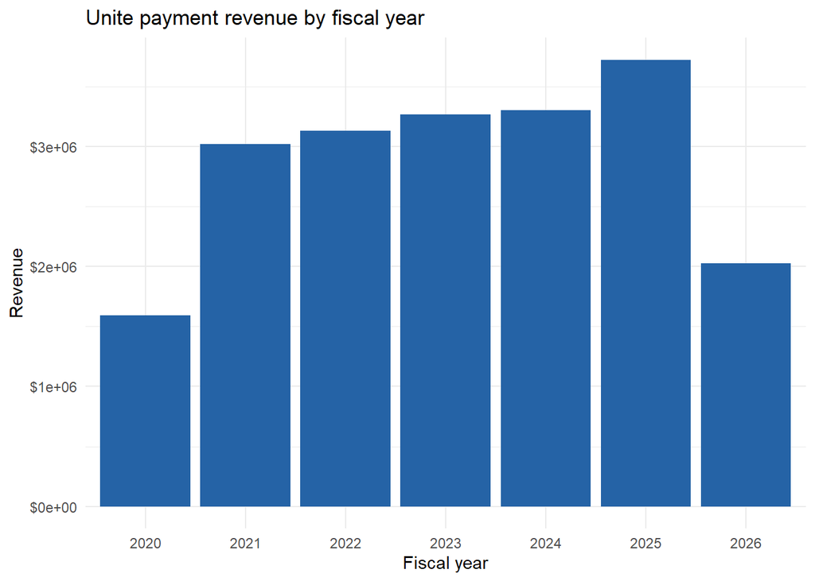

```r
# Plot annual revenue and investigate discontinuities before drawing conclusions.
ggplot(unite_by_year, aes(factor(fiscal_year), revenue)) +
  geom_col(fill = "#2563A6") +
  scale_y_continuous(labels = function(x) paste0("$", format(x, big.mark = ",", trim = TRUE))) +
  labs(title = "Unite payment revenue by fiscal year", x = "Fiscal year", y = "Revenue") +
  theme_minimal()
```

```
$20,079,042 of revenue generated since 2020.
```

```
Highest revenue: $3,725,836 in fiscal year 2025.
```

```
Lowest revenue: $1,594,886 in fiscal year 2020.
```

```r
gt(head(unite_mix, 10))
```

| gift_type | tender_type | payments | revenue |
| --- | --- | --- | --- |
| Renew | Legacy | 522344 | 5240326 |
| Renew | Credit Card | 448162 | 4472275 |
| Renew | EFT | 230541 | 2257339 |
| New | Legacy | 121859 | 1240100 |
| New | Credit Card | 106566 | 1053426 |
| Upgrade | Legacy | 20130 | 679715 |
| Upgrade | Credit Card | 14958 | 650203 |
| Additional | Legacy | 18754 | 633547 |
| New | EFT | 53767 | 542851 |
| Additional | Credit Card | 16142 | 531668 |

```
Highest revenue: $8,437,947 from tender type Legacy.
```

```
Lowest revenue: $600 from tender type Wire.
```

## Legacy Team Approach payments

Legacy records have household-gift grain and can link to several constituent IDs. Do not append their rows to Unite and call the result donor-level data. First inspect link availability, time range, values, and communication channels; later aggregate to an explicit donor-year rule.

```r
# Parse legacy dates and quantify constituent-link completeness.
legacy <- read_project_csv("team_approach_legacy_payments.csv") %>%
  mutate(gift_date = as.Date(gift_date), fiscal_year = fiscal_year(gift_date))

legacy_quality <- legacy %>%
  summarise(nonpositive_amounts = sum(is.na(payment_amount) | payment_amount <= 0),
            missing_dates = sum(is.na(gift_date)),
            first_constituent_link = sum(!is.na(constituent_id_1) & constituent_id_1 != ""),
            no_constituent_link = sum(if_all(starts_with("constituent_id_"), ~ is.na(.x) | .x == "")))

legacy_year <- legacy %>%
  group_by(fiscal_year) %>%
  summarise(gifts = n(), revenue = sum(payment_amount, na.rm = TRUE),
            median_gift = median(payment_amount, na.rm = TRUE), .groups = "drop")

legacy_channels <- legacy %>%
  group_by(communication_method, communication_type) %>%
  summarise(gifts = n(), revenue = sum(payment_amount, na.rm = TRUE), .groups = "drop") %>%
  arrange(desc(revenue))
```

```r
gt(profile_data(legacy, "team_approach_legacy_payments.csv", "ta_account_id"))
```

| file | rows | columns | key | missing_key_values | duplicate_nonmissing_keys |
| --- | --- | --- | --- | --- | --- |
| team_approach_legacy_payments.csv | 1202857 | 45 | ta_account_id | 0 | 614014 |

```
Unique rows: 588843
```

```r
gt(legacy_quality)
```

| nonpositive_amounts | missing_dates | first_constituent_link | no_constituent_link |
| --- | --- | --- | --- |
| 0 | 0 | 986729 | 216128 |

```r
gt(tail(legacy_year, 12))
```

| fiscal_year | gifts | revenue | median_gift |
| --- | --- | --- | --- |
| 2009 | 38528 | 1194249 | 8 |
| 2010 | 38938 | 1127895 | 8 |
| 2011 | 39175 | 1278503 | 8 |
| 2012 | 38845 | 1311924 | 8 |
| 2013 | 51911 | 1700439 | 8 |
| 2014 | 60294 | 1676100 | 8 |
| 2015 | 62739 | 1724809 | 8 |
| 2016 | 79249 | 1966432 | 8 |
| 2017 | 96191 | 2451858 | 8 |
| 2018 | 110971 | 2902201 | 8 |
| 2019 | 129335 | 3217897 | 8 |
| 2020 | 22976 | 1278235 | 30 |

```r
gt(head(legacy_channels, 15))
```

| communication_method | communication_type | gifts | revenue |
| --- | --- | --- | --- |
| Synthetic | Synthetic | 1202857 | 35215057 |

## Campaign Codes and Solicitation History

Campaign codes are reference data; campaign members are solicitation records. The anti-join checks whether every solicitation points to a known code. Response rates are descriptive, not causal measures of campaign effectiveness.

```r
# Load both campaign tables only while their relationship is being tested.
campaign_codes <- read_project_csv("campaign_codes.csv")

campaign_members <- read_project_csv("campaign_members.csv") %>%
  mutate(campaign_start_date = as.Date(campaign_start_date),
         fiscal_year = fiscal_year(campaign_start_date))

campaign_results <- campaign_members %>%
  group_by(fiscal_year) %>%
  summarise(solicitations = n(), constituents = n_distinct(constituent_id),
            responses = sum(responded, na.rm = TRUE),
            response_rate_pct = 100 * mean(responded, na.rm = TRUE), .groups = "drop")

campaign_rank <- campaign_members %>%
  group_by(marketing_code, campaign_name) %>%
  summarise(solicitations = n(), responses = sum(responded, na.rm = TRUE),
            response_rate_pct = 100 * mean(responded, na.rm = TRUE), .groups = "drop") %>%
  filter(solicitations >= 30) %>% arrange(desc(response_rate_pct), desc(solicitations))
```

```r
gt(profile_data(campaign_codes, "campaign_codes.csv", "Marketing Code"))|>
  tab_header(
    title = "Campaign Code Data Profile"
  )
```

Campaign Code Data Profile

| file | rows | columns | key | missing_key_values | duplicate_nonmissing_keys |
| --- | --- | --- | --- | --- | --- |
| campaign_codes.csv | 29249 | 17 | Marketing Code | 0 | 0 |

29,249 rows; 0 missing; 0 duplicates

```r
gt(campaign_results)
```

| fiscal_year | solicitations | constituents | responses | response_rate_pct |
| --- | --- | --- | --- | --- |
| 2020 | 504933 | 41992 | 10608 | 2.100873 |
| 2021 | 675165 | 58675 | 11107 | 1.645079 |
| 2022 | 969988 | 90433 | 11912 | 1.228056 |
| 2023 | 1065866 | 100658 | 12195 | 1.144140 |
| 2024 | 892825 | 80102 | 12268 | 1.374065 |
| 2025 | 1124627 | 101978 | 14617 | 1.299720 |

```
Average solicitation response rate: 1.47 percent
```

```r
gt(head(campaign_rank, 5))
```

| marketing_code | campaign_name | solicitations | responses | response_rate_pct |
| --- | --- | --- | --- | --- |
| SYN-CODE-000456 | Synthetic Campaign 000456 | 901 | 673 | 74.69478 |
| SYN-CODE-007429 | Synthetic Campaign 007429 | 804 | 593 | 73.75622 |
| SYN-CODE-015039 | Synthetic Campaign 015039 | 809 | 593 | 73.30037 |
| SYN-CODE-017116 | Synthetic Campaign 017116 | 854 | 617 | 72.24824 |
| SYN-CODE-010466 | Synthetic Campaign 010466 | 682 | 478 | 70.08798 |

Most effective campaign: Synthetic Campaign 000456

```r
gt(tail(campaign_rank, 5))
```

| marketing_code | campaign_name | solicitations | responses | response_rate_pct |
| --- | --- | --- | --- | --- |
| SYN-CODE-028114 | Synthetic Campaign 028114 | 30 | 0 | 0 |
| SYN-CODE-028381 | Synthetic Campaign 028381 | 30 | 0 | 0 |
| SYN-CODE-028488 | Synthetic Campaign 028488 | 30 | 0 | 0 |
| SYN-CODE-028597 | Synthetic Campaign 028597 | 30 | 0 | 0 |
| SYN-CODE-029130 | Synthetic Campaign 029130 | 30 | 0 | 0 |

Least effective campaign: Synthetic Campaign 028114

## Soft credits

Soft credits are attributed recognition, rather than necessarily direct cash paid by the recipient. They should stay separate from payments until a later metric applies the documented duplicate-removal and attribution rules.

```r
# Examine unique credits, orphan recipients, amount validity, and organization type.
soft <- read_project_csv("soft_credits.csv") %>%
  mutate(credit_date = as.Date(.data[["Credit Date"]]), fiscal_year = fiscal_year(credit_date))
soft_quality <- soft %>%
  summarise(exact_duplicate_rows = sum(duplicated(soft)),
            orphan_recipients = sum(.data[["Soft Credit Constituent ID"]] == "SYN-ORPHAN", na.rm = TRUE),
            nonpositive_amounts = sum(is.na(.data[["Credit Amount"]]) | .data[["Credit Amount"]] <= 0),
            first_date = min(credit_date, na.rm = TRUE), last_date = max(credit_date, na.rm = TRUE))
soft_mix <- soft %>%
  group_by(.data[["Hard Credit Org Type"]], .data[["Credit Gift Type"]]) %>%
  summarise(credits = n(), amount = sum(.data[["Credit Amount"]], na.rm = TRUE),
            median_amount = median(.data[["Credit Amount"]], na.rm = TRUE), .groups = "drop") %>%
  arrange(desc(amount))
```

```r
gt(profile_data(soft, "soft_credits.csv", "Credit ID"))
```

| file | rows | columns | key | missing_key_values | duplicate_nonmissing_keys |
| --- | --- | --- | --- | --- | --- |
| soft_credits.csv | 4145 | 11 | Credit ID | 0 | 79 |

```r
gt(soft_quality)
```

| exact_duplicate_rows | orphan_recipients | nonpositive_amounts | first_date | last_date |
| --- | --- | --- | --- | --- |
| 79 | 79 | 34 | 2020-07-01 | 2026-06-29 |

```r
gt(soft_mix)
```

| Hard Credit Org Type | Credit Gift Type | credits | amount | median_amount |
| --- | --- | --- | --- | --- |
| Other Sponsor | Payment | 3403 | 1514548 | 162 |
| DAF Sponsor | Payment | 742 | 342279 | 236 |

## Cultivation assignments and officer portfolios

Cultivation has constituent-year grain while portfolios are reference records. The following relationship check and funnel help assess capacity, selection, contact, and holdout patterns. Holdout comparisons require further validation before causal interpretation.

```r
# Join portfolio capacity to cultivation summaries and report unmatched assignments.
portfolios <- read_project_csv("officer_portfolios.csv")

cultivation <- read_project_csv("cultivation.csv")

cultivation_links <- cultivation %>%
  anti_join(portfolios, by = "portfolio_id") %>%
  summarise(unmatched_rows = n(), unmatched_portfolios = n_distinct(portfolio_id))

cultivation_funnel <- cultivation %>%
  group_by(fiscal_year, portfolio_id) %>%
  summarise(assignments = n(), selected = sum(selected, na.rm = TRUE),
            contacted = sum(contacted, na.rm = TRUE), holdout = sum(holdout, na.rm = TRUE),
            adopted = first(program_adopted), .groups = "drop") %>%
  left_join(select(portfolios, portfolio_id, capacity, rollout_fy), by = "portfolio_id") %>%
  mutate(selection_rate_pct = 100 * selected / assignments,
         contact_rate_of_selected_pct = if_else(selected > 0, 100 * contacted / selected, NA_real_))
```

```r
gt(profile_data(portfolios, "officer_portfolios.csv", "portfolio_id"))
```

| file | rows | columns | key | missing_key_values | duplicate_nonmissing_keys |
| --- | --- | --- | --- | --- | --- |
| officer_portfolios.csv | 8 | 4 | portfolio_id | 0 | 0 |

```r
cultivation_funnel |>
  filter(fiscal_year == 2025) |>
  gt() |>
    tab_header(
    title = "Latest Year Portfolios"
  )
```

Latest Year Portfolios

| fiscal_year | portfolio_id | assignments | selected | contacted | holdout | adopted | capacity | rollout_fy | selection_rate_pct | contact_rate_of_selected_pct |
| --- | --- | --- | --- | --- | --- | --- | --- | --- | --- | --- |
| 2025 | P01 | 125 | 125 | 94 | 31 | TRUE | 125 | 2023 | 100 | 75.2 |
| 2025 | P02 | 125 | 125 | 94 | 31 | TRUE | 125 | 2023 | 100 | 75.2 |
| 2025 | P03 | 125 | 125 | 94 | 31 | TRUE | 125 | 2024 | 100 | 75.2 |
| 2025 | P04 | 125 | 125 | 94 | 31 | TRUE | 125 | 2024 | 100 | 75.2 |
| 2025 | P05 | 125 | 125 | 94 | 31 | TRUE | 125 | 2025 | 100 | 75.2 |
| 2025 | P06 | 125 | 125 | 94 | 31 | TRUE | 125 | 2025 | 100 | 75.2 |
| 2025 | P07 | 125 | 125 | 94 | 31 | FALSE | 125 | 2026 | 100 | 75.2 |
| 2025 | P08 | 125 | 125 | 94 | 31 | FALSE | 125 | NA | 100 | 75.2 |

```r
rm(portfolios, cultivation, cultivation_links, cultivation_funnel)
gc()
```

```
          used  (Mb) gc trigger  (Mb)  max used   (Mb)
Ncells 1900035 101.5    5595416 298.9   8287812  442.7
Vcells 4582152  35.0   71016695 541.9 138617609 1057.6
```

## Passport viewing data

```r
# Import Passport viewing data
passport <- read_project_csv("passport_viewing.txt")

passport_summary <- passport %>%
  summarise(
    records = n(),
    linked_constituents = n_distinct(constituent_id, na.rm = TRUE),
    total_titles_viewed = sum(titles_viewed, na.rm = TRUE),
    median_completion_pct = median(mean_percent_watched, na.rm = TRUE)
  )

passport_content <- passport %>%
  group_by(fiscal_year, genre) %>%
  summarise(
    constituents = n_distinct(constituent_id, na.rm = TRUE),
    titles_viewed = sum(titles_viewed, na.rm = TRUE),
    mean_completion_pct = mean(mean_percent_watched, na.rm = TRUE),
    .groups = "drop"
  ) %>%
  arrange(desc(constituents), desc(titles_viewed))
```

```r
gt(profile_data(passport, "passport_viewing.txt", "constituent_id")) |>
    tab_header(
    title = "Passport Data Profile"
  )
```

Passport Data Profile

| file | rows | columns | key | missing_key_values | duplicate_nonmissing_keys |
| --- | --- | --- | --- | --- | --- |
| passport_viewing.txt | 444741 | 5 | constituent_id | 0 | 374226 |

```r
gt(passport_summary)
```

| records | linked_constituents | total_titles_viewed | median_completion_pct |
| --- | --- | --- | --- |
| 444741 | 70515 | 4017279 | 0.80668 |

```r
gt(head(passport_content, 20))
```

| fiscal_year | genre | constituents | titles_viewed | mean_completion_pct |
| --- | --- | --- | --- | --- |
| 2026 | Drama | 20198 | 387249 | 0.8065738 |
| 2023 | Drama | 16796 | 305007 | 0.8043744 |
| 2024 | Drama | 16387 | 297597 | 0.8037019 |
| 2022 | Drama | 15942 | 288480 | 0.8023395 |
| 2025 | Drama | 15912 | 297131 | 0.8054795 |
| 2021 | Drama | 15686 | 287795 | 0.8047723 |
| 2026 | History | 13331 | 88513 | 0.6750119 |
| 2026 | Science and Nature | 11903 | 100000 | 0.6659719 |
| 2023 | History | 10893 | 69995 | 0.6819851 |
| 2024 | History | 10621 | 69328 | 0.6710287 |
| 2025 | History | 10403 | 66289 | 0.6706038 |
| 2022 | History | 10228 | 66305 | 0.6743409 |
| 2021 | History | 10080 | 64735 | 0.6738158 |
| 2026 | Arts and Music | 9752 | 41264 | 0.5956439 |
| 2023 | Science and Nature | 9625 | 80039 | 0.6621882 |
| 2024 | Science and Nature | 9499 | 78986 | 0.6679067 |
| 2026 | Culture | 9429 | 49241 | 0.7018895 |
| 2022 | Science and Nature | 9268 | 74400 | 0.6674242 |
| 2025 | Science and Nature | 9231 | 76352 | 0.6665065 |
| 2021 | Science and Nature | 8966 | 71739 | 0.6628395 |

```
Most titles viewed: 1,863,259 in genre Drama.
```

```
Fewest titles viewed: 44,242 in genre Other.
```

## Key Findings

The analysis also identified important considerations for future modeling, including missing demographic information, differences in how datasets are structured, and the need to distinguish direct donations from soft credits. Overall, these datasets provide a foundation for identifying patterns in constituent giving and engagement that may help PBS Utah prioritize potential major donors. Further analysis will be needed to determine which characteristics are most useful for identifying constituents with the potential to increase their annual giving.

## AI Disclosure

I used OpenAI Codex to create the initial EDA file template, including section headers and code to load and clear datasets to reduce memory usage. After running and reviewing the code chunks, I added cat() statements and additional analyses to summarize key findings and connect the results throughout the report.